# Graphs in R using ggplot2: Receiver Operating Characteristic Curves

⇦ Back

This page just talks about how to *plot* receiver operating characteristic (ROC) curves. For more on what they are and how to use them, see this tutorial. Briefly, a ROC curve illustrates how the diagnostic accuracy (ie the sensitivity and specificity) of a binary classification test (eg predicting whether something did or didn’t happen) changes as its threshold changes.

# 1 Example Data

A good data set to use is the training data subset from the `titanic` package. This contains information about the passengers on board the Titanic, how much they paid for their fare and whether or not they survived. Install this package in R with:

```r
# Install the package
install.packages("titanic", repos = "http://cran.us.r-project.org")
```

Then load and take a look at the data:

```r
# Load the package
library(titanic)
# Change the width of the console
options("width" = 200)
# Take a look at the first 6 rows of the data
head(titanic_train[c("Survived", "Pclass", "Name", "Sex", "Age", "Fare", "Cabin", "Embarked")])
```

```
##   Survived Pclass                                                Name    Sex Age    Fare Cabin Embarked
## 1        0      3                             Braund, Mr. Owen Harris   male  22  7.2500              S
## 2        1      1 Cumings, Mrs. John Bradley (Florence Briggs Thayer) female  38 71.2833   C85        C
## 3        1      3                              Heikkinen, Miss. Laina female  26  7.9250              S
## 4        1      1        Futrelle, Mrs. Jacques Heath (Lily May Peel) female  35 53.1000  C123        S
## 5        0      3                            Allen, Mr. William Henry   male  35  8.0500              S
## 6        0      3                                    Moran, Mr. James   male  NA  8.4583              Q
```

# 2 Calculating Thresholds

Fortunately for us, there is a function that can do most of the work when it comes to ROC analysis: the unsurprisingly named `roc()` function. It comes with the `pROC` library which you can install via the following:

```r
# Install the package
install.packages("pROC", repos = "http://cran.us.r-project.org")
```

Then load and use:

```r
library(pROC)

r <- roc(Survived ~ Fare, data = titanic_train)
```

Have a look at some of the thresholds (ie values for fare that will be taken as cut-offs) that this function produced:

```r
head(r$thresholds)
```

```
## [1]    -Inf 2.00625 4.50625 5.61875 6.33750 6.44375
```

# 3 Plot

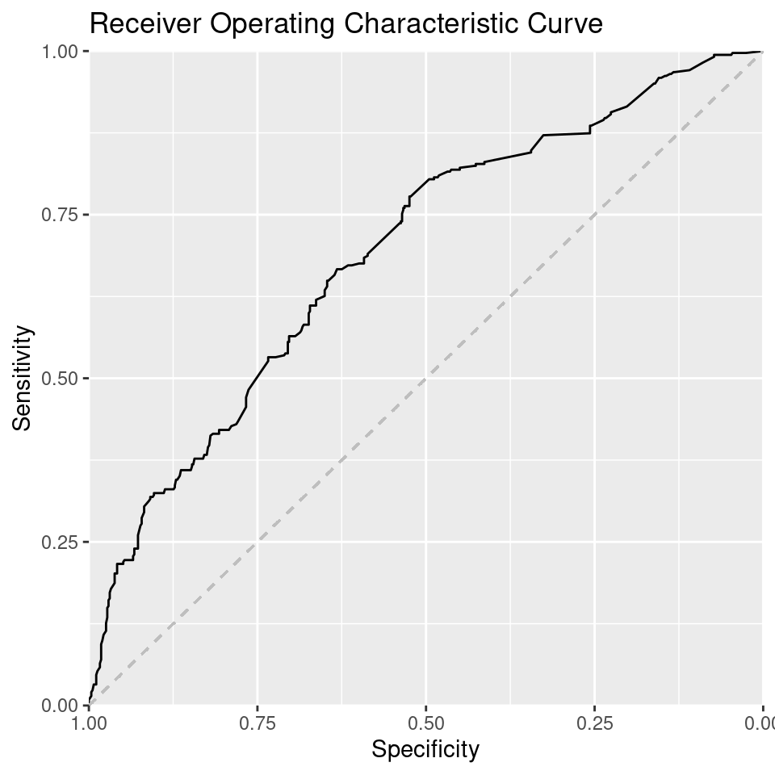

```r
library(ggplot2)

p <- ggroc(r)
p <- p + ggtitle("Receiver Operating Characteristic Curve")
p <- p + ylab("Sensitivity")
p <- p + xlab("Specificity")
p <- p + geom_segment(
    aes(x = 1, xend = 0, y = 0, yend = 1), color = "grey", linetype = "dashed"
)
p <- p + scale_y_continuous(expand = c(0, 0))
p <- p + scale_x_reverse(expand = c(0, 0))
print(p)
```

Get the area under the curve and the 95% confidence interval of this area (which should be rounded off to 2 decimal places):

```r
auc <- auc(r)
ci <- ci.auc(r)
ci_l <- round(ci[1], 2)
ci_u <- round(ci[3], 2)
```

Add this information to the graph:

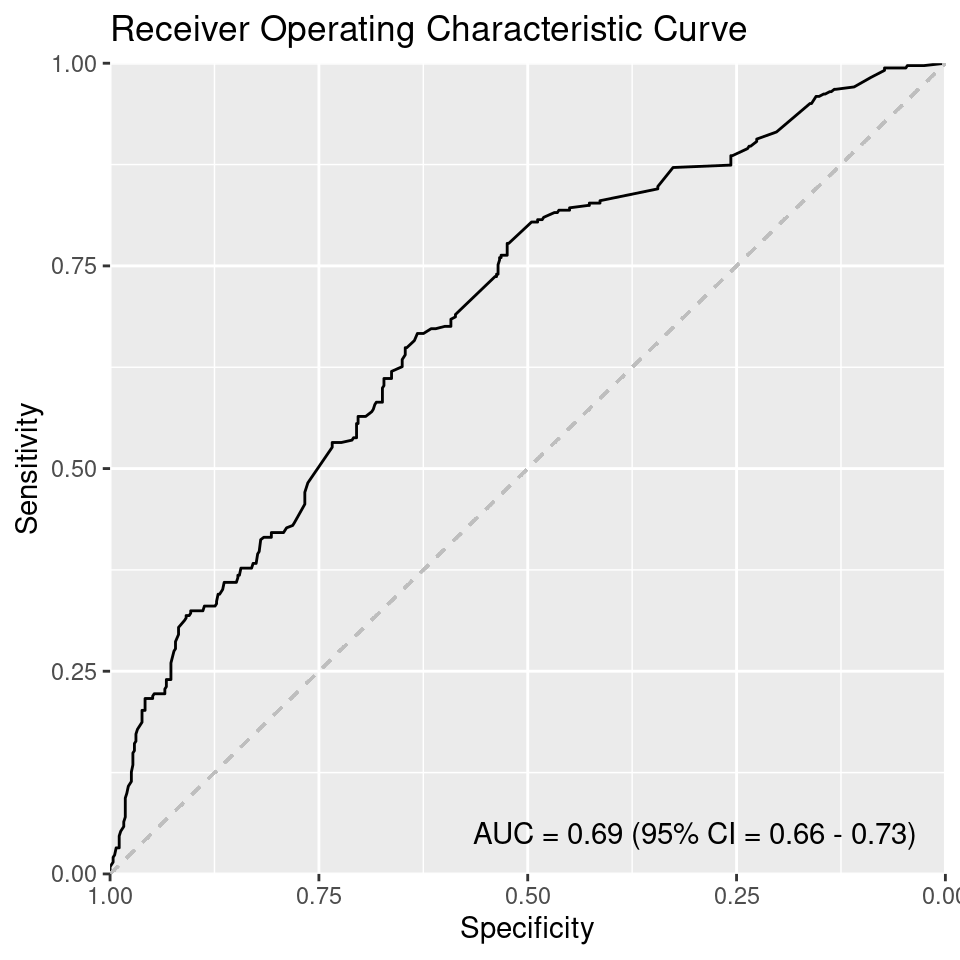

```r
p <- ggroc(r)
p <- p + ggtitle("Receiver Operating Characteristic Curve")
p <- p + ylab("Sensitivity")
p <- p + xlab("Specificity")
p <- p + geom_segment(
    aes(x = 1, xend = 0, y = 0, yend = 1), color = "grey", linetype = "dashed"
)
p <- p + scale_y_continuous(expand = c(0, 0))
p <- p + scale_x_reverse(expand = c(0, 0))
legend_text <- paste0(
    "AUC = ", round(auc, 2), " (95% CI = ", ci_l, " - ", ci_u, ")"
)
p <- p + annotate("text", x = 0.3, y = 0.05, label = legend_text)
print(p)
```

The area under the curve is 0.69; not particularly high! It seems that fare can’t be used as an accurate predictor of passenger survival.

⇦ Back